# Red Wine Quality Exploration

### 3.3.2 Quality vs Volatile Acidity

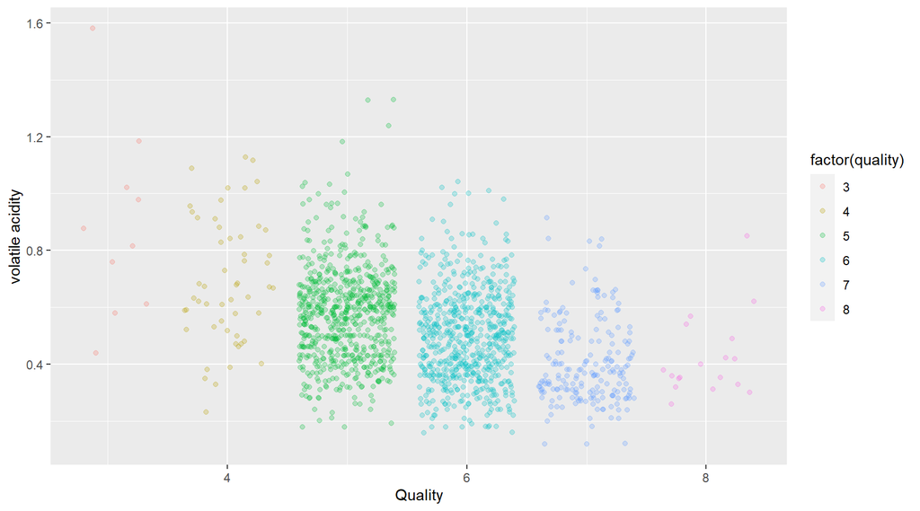

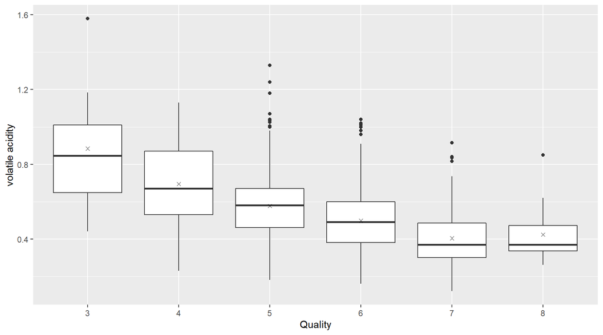

```
##
##  Pearson's product-moment correlation
##
## data:  pf$volatile.acidity and pf$quality
## t = -16.954, df = 1597, p-value < 2.2e-16
## alternative hypothesis: true correlation is not equal to 0
## 95 percent confidence interval:
##  -0.4313210 -0.3482032
## sample estimates:
##        cor
## -0.3905578
```

```
## [1] "volatile.acidity summary"
```

```
##    Min. 1st Qu.  Median    Mean 3rd Qu.    Max.
##  0.1200  0.3900  0.5200  0.5278  0.6400  1.5800
```

```
## pf$quality: 3
##    Min. 1st Qu.  Median    Mean 3rd Qu.    Max.
##  0.4400  0.6475  0.8450  0.8845  1.0100  1.5800
## ------------------------------------------------------------
## pf$quality: 4
##    Min. 1st Qu.  Median    Mean 3rd Qu.    Max.
##   0.230   0.530   0.670   0.694   0.870   1.130
## ------------------------------------------------------------
## pf$quality: 5
##    Min. 1st Qu.  Median    Mean 3rd Qu.    Max.
##   0.180   0.460   0.580   0.577   0.670   1.330
## ------------------------------------------------------------
## pf$quality: 6
##    Min. 1st Qu.  Median    Mean 3rd Qu.    Max.
##  0.1600  0.3800  0.4900  0.4975  0.6000  1.0400
## ------------------------------------------------------------
## pf$quality: 7
##    Min. 1st Qu.  Median    Mean 3rd Qu.    Max.
##  0.1200  0.3000  0.3700  0.4039  0.4850  0.9150
## ------------------------------------------------------------
## pf$quality: 8
##    Min. 1st Qu.  Median    Mean 3rd Qu.    Max.
##  0.2600  0.3350  0.3700  0.4233  0.4725  0.8500
```

### 3.3.3 Quality vs Sulphates

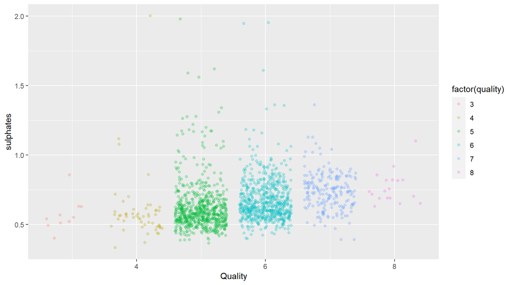

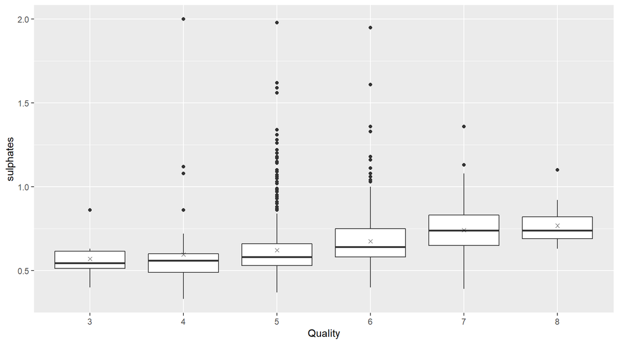

```
##
##  Pearson's product-moment correlation
##
## data:  pf$sulphates and pf$quality
## t = 10.38, df = 1597, p-value < 2.2e-16
## alternative hypothesis: true correlation is not equal to 0
## 95 percent confidence interval:
##  0.2049011 0.2967610
## sample estimates:
##       cor
## 0.2513971
```

```
## [1] "sulphates summary"
```

```
##    Min. 1st Qu.  Median    Mean 3rd Qu.    Max.
##  0.3300  0.5500  0.6200  0.6581  0.7300  2.0000
```

```
## pf$quality: 3
##    Min. 1st Qu.  Median    Mean 3rd Qu.    Max.
##  0.4000  0.5125  0.5450  0.5700  0.6150  0.8600
## ------------------------------------------------------------
## pf$quality: 4
##    Min. 1st Qu.  Median    Mean 3rd Qu.    Max.
##  0.3300  0.4900  0.5600  0.5964  0.6000  2.0000
## ------------------------------------------------------------
## pf$quality: 5
##    Min. 1st Qu.  Median    Mean 3rd Qu.    Max.
##   0.370   0.530   0.580   0.621   0.660   1.980
## ------------------------------------------------------------
## pf$quality: 6
##    Min. 1st Qu.  Median    Mean 3rd Qu.    Max.
##  0.4000  0.5800  0.6400  0.6753  0.7500  1.9500
## ------------------------------------------------------------
## pf$quality: 7
##    Min. 1st Qu.  Median    Mean 3rd Qu.    Max.
##  0.3900  0.6500  0.7400  0.7413  0.8300  1.3600
## ------------------------------------------------------------
## pf$quality: 8
##    Min. 1st Qu.  Median    Mean 3rd Qu.    Max.
##  0.6300  0.6900  0.7400  0.7678  0.8200  1.1000
```

Above is a relatively weak correlation (0.25 for sulphates vs quality), but since our primary interest is quality, I wanted to explore as many variables  
as possible (that correlate with quality). As expected, with a weak correlation, there is only a slight difference between the levels. But it is a positive correlation, as the sulphates increase, so does the wine’s quality. I thought it was interesting that the highest quality level (8), has a minimum sulphate level of 0.63, close to the median level for the other quality ratings.

### 3.3.4 Quality vs Citric Acid

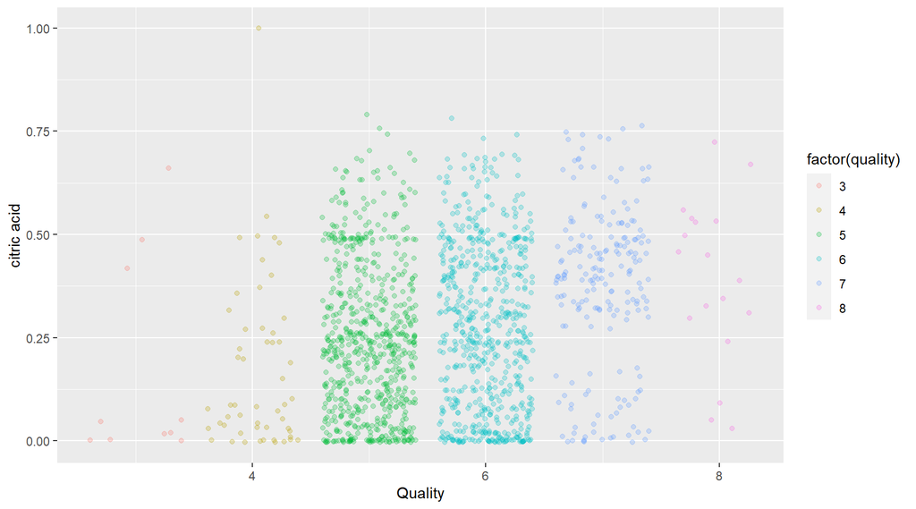

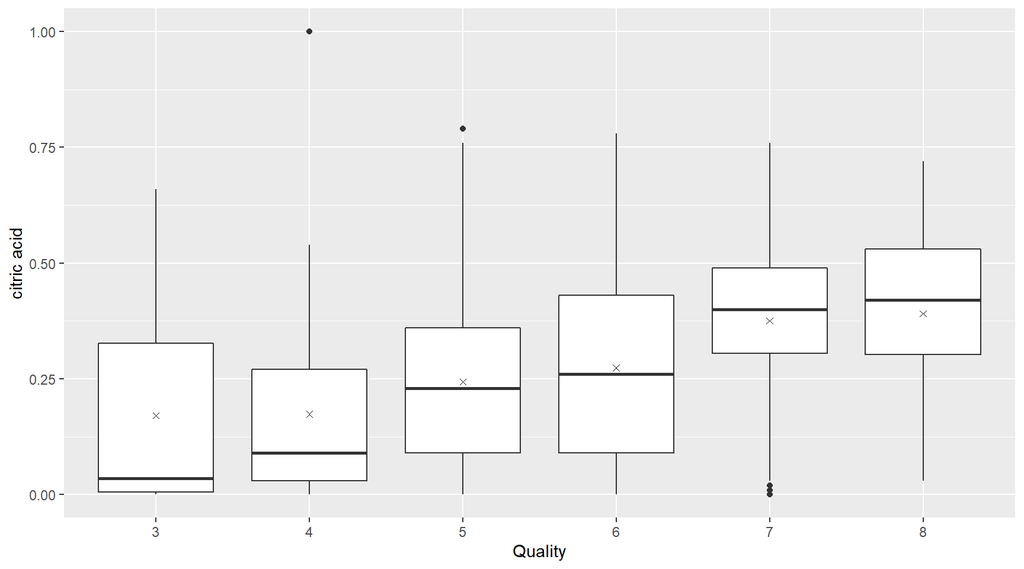

```
##
##  Pearson's product-moment correlation
##
## data:  pf$citric.acid and pf$quality
## t = 9.2875, df = 1597, p-value < 2.2e-16
## alternative hypothesis: true correlation is not equal to 0
## 95 percent confidence interval:
##  0.1793415 0.2723711
## sample estimates:
##       cor
## 0.2263725
```

```
## [1] "citric.acid summary"
```

```
##    Min. 1st Qu.  Median    Mean 3rd Qu.    Max.
##   0.000   0.090   0.260   0.271   0.420   1.000
```

```
## pf$quality: 3
##    Min. 1st Qu.  Median    Mean 3rd Qu.    Max.
##  0.0000  0.0050  0.0350  0.1710  0.3275  0.6600
## ------------------------------------------------------------
## pf$quality: 4
##    Min. 1st Qu.  Median    Mean 3rd Qu.    Max.
##  0.0000  0.0300  0.0900  0.1742  0.2700  1.0000
## ------------------------------------------------------------
## pf$quality: 5
##    Min. 1st Qu.  Median    Mean 3rd Qu.    Max.
##  0.0000  0.0900  0.2300  0.2437  0.3600  0.7900
## ------------------------------------------------------------
## pf$quality: 6
##    Min. 1st Qu.  Median    Mean 3rd Qu.    Max.
##  0.0000  0.0900  0.2600  0.2738  0.4300  0.7800
## ------------------------------------------------------------
## pf$quality: 7
##    Min. 1st Qu.  Median    Mean 3rd Qu.    Max.
##  0.0000  0.3050  0.4000  0.3752  0.4900  0.7600
## ------------------------------------------------------------
## pf$quality: 8
##    Min. 1st Qu.  Median    Mean 3rd Qu.    Max.
##  0.0300  0.3025  0.4200  0.3911  0.5300  0.7200
```

# 4 Bivariate Analysis

### 4.0.1 Talk about some of the relationships you observed in this part of the

investigation. How did the feature(s) of interest vary with other features in the dataset?

We have just finished plotting various positive and negative correlations between variables in the dataset. We used several different plot styles to give a different perspective on the data. We are most interested in red wine quality, so we examined 4 different variables against quality. The strongest correlation we found towards quality was with alcohol (the more alcohol, the higher quality of the wine).

### 4.0.2 Did you observe any interesting relationships between the other features

(not the main feature(s) of interest)?

The three highest positive correlations all had corr 0.67.  
These correlations were:  
1) fixed acidity vs citric acid  
2) fixed acidity vs density  
3) total sulfur dioxide vs free sulfur dioxide  
The top and the bottom one (fixed acidity vs citric acid and total sulfur dioxide vs free sulfur dioxide) were not surprising since they are both acids and the other both sulfur dioxide.

### 4.0.3 What was the strongest relationship you found?

The relationship between pH and fixed acidity has the strongest correlation in the dataset (corr -0.68).

# 5 Multivariate Plots Section

### 5.0.1 Fixed acidity vs Density with Quality

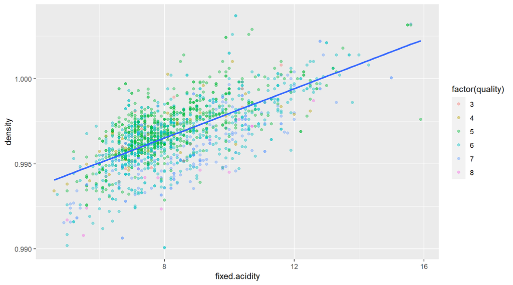

### 5.0.2 Citric acid vs pH with Quality

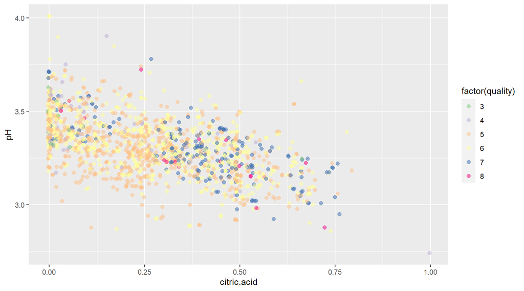

We used the correlation between pH and citric acid (-0.54) and added quality to it for our second multivariate plot. The result was not helpful. Our top-quality rating of ‘8’ appears at all levels on this chart. It looks like there is no correlation between quality and these two variables.

### 5.0.3 Alcohol vs Volatile Acidity with Quality

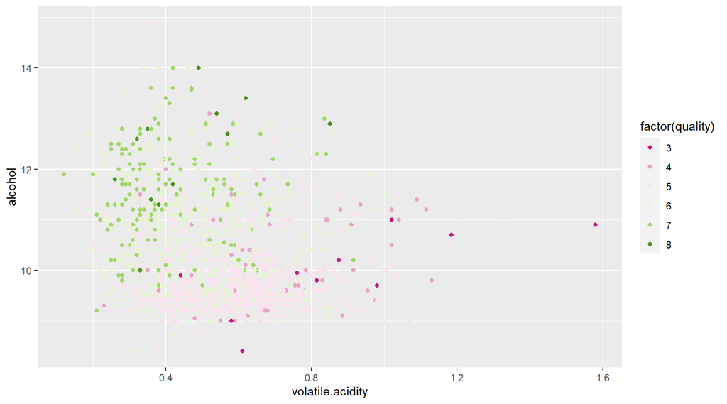

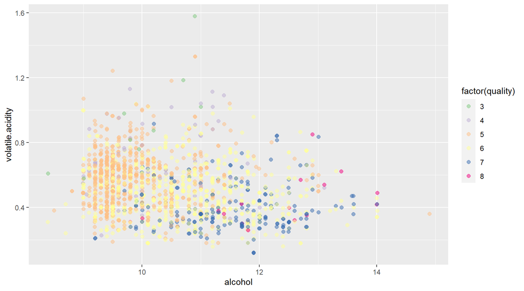

Here we have the two variables with the highest correlation with quality and then added quality to them. These results were not surprising as we already knew higher quality red wines had higher levels of alcohol and lower levels of volatile acidity. However, they are still interesting to look at in the plots. I could not decide which way I wanted to plot these, with alcohol on the x-axis or on the y-axis, so I did one of each. The first plot turned out to be my favorite, so this will be in my final plot section.

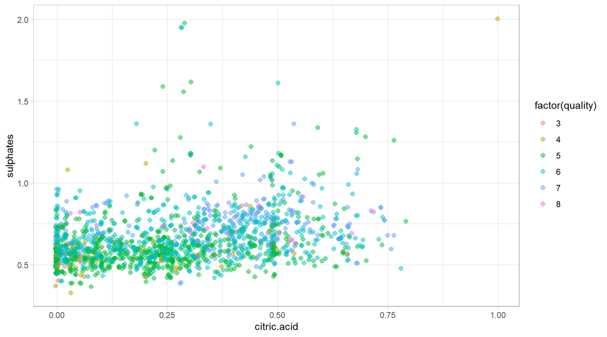

The remaining two variables we looked at, with correlations to quality, are Sulphates and citric acid. So we used those two variables in this plot and added quality to them. This turned out a little interesting. Because most quality levels are between 5-6, this plot is not very clear. Nevertheless, it is noticeable that quality levels 7 & 8 seem to fall between sulphate levels .4 to .8 (roughly). The sulphate outliners drop back down to average quality wine. Citric acid levels do not seem to matter as much as we can see high levels throughout the spread of citric acid.

# 6 Multivariate Analysis

### 6.0.1 Talk about some of the relationships you observed in this part of the

investigation. Were there features that strengthened each other in terms of looking at your feature(s) of interest?

In our plots, we found that high-quality wines contain higher levels of alcohol, sulphates, and citric acid. And lower levels of volatile acidity.

### 6.0.3 OPTIONAL: Did you create any models with your dataset? Discuss the

No models were made.

# 7 Final Plots and Summary

### 7.0.1 Plot One

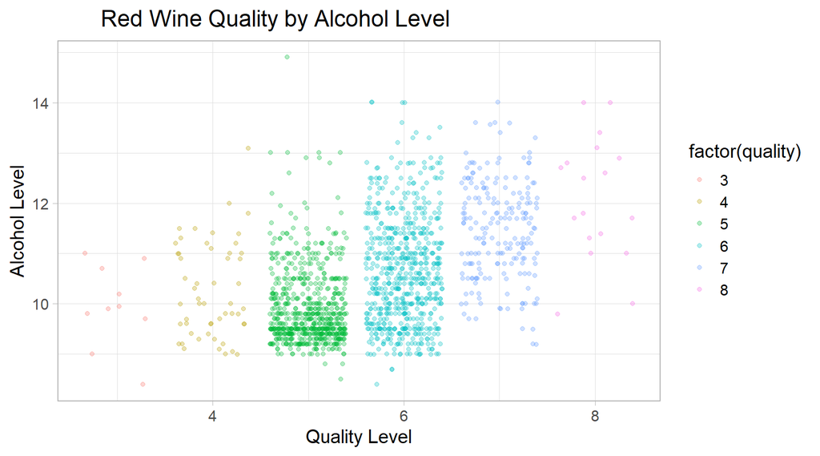

### 7.0.3 Plot Two

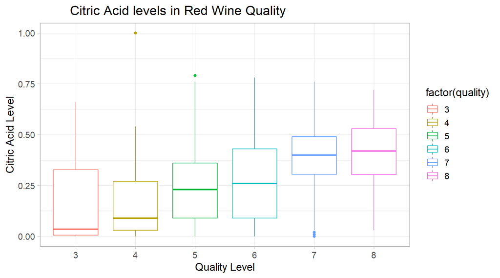

### 7.0.4 Description Two

I selected this plot because I found it surprising. The correlation between quality and citric acid was relatively weak, being 0.23, so I did not expect this boxplot to show a nice steady increase in quality, as the level of citric acid went up. I added some color onto it because I enjoy seeing the color. Even though we have a limited sample size, and the amounts of citric acid are minimal, it appears the level of citric acid used could play a role in the quality produced.

### 7.0.5 Plot Three

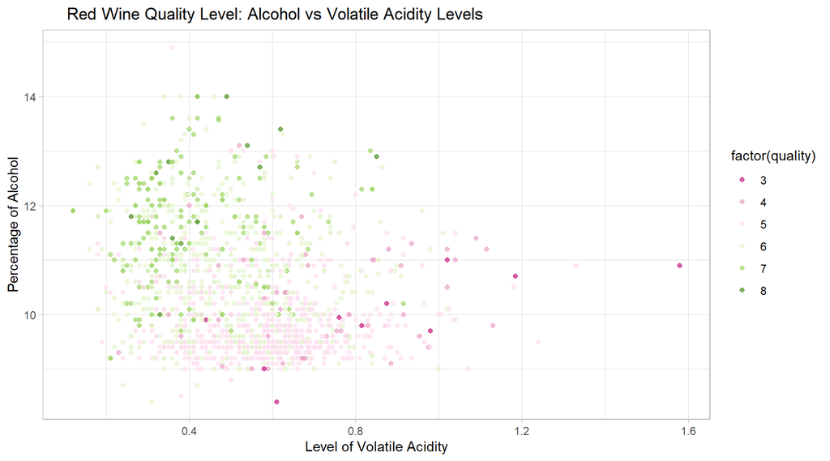

### 7.0.6 Description Three

I saved this plot for last because it is my favorite. This plot has wine quality along with the two highest correlations to wine quality. Alcohol has a correlation of 0.48, and volatile acidity’s correlation is -0.39. I  
like to see how these two variables come together, matched up with quality. With the greens and pinks, it makes it stand out, higher levels of alcohol along with low levels of volatile acidity equal better red wine quality.

# 8 Reflection

In this dataset, we examined 1,599 different red wines. The goal was to determine which variables contributed to the quality of the wine. I started by spending time looking at each variable individually.

Then I checked the correlation between the variables. It was surprising to find that the highest correlation was only -0.68. I had expected alcohol level to have a higher correlation, but then I suppose that would make it too easy to produce quality wine. If the alcohol level were the key, wine makers could9 increase the alcohol level and be done with it, but nothing is ever that simple. After that, then I spent some time plotting the correlations of interest. I had hoped there would be more variables correlate with quality, but I used what we had. The most surprising plot for me was the correlation between quality and citric acid. It had a very weak correlation, and citric acid levels are very low in wine in general. I did not expect to see much of anything when I plotted these two variables. However, instead, we saw a very definite increase in quality as the citric acid level increased.

In the multivariate plots, we were able to get a look at three variables together. My favorite plot was putting alcohol, volatile acidity, and quality together. I had examined these variables separately, but bringing them together painted a nice picture of red wine quality (higher alcohol levels, along with lower volatile acidity = better red wine quality).

I selected the smallest dataset to use for this project. Now I wonder how this would have gone had I selected the dataset with a larger sample size. I would have like to see the quality ratings on a larger sample size. I am curious if we would still see 95% of the wines falling between a quality rating of 5-7 or getting more variety. Had there been more wines with the highest quality rating, perhaps it would have been easier to determine which chemical properties influence the quality of red wines.

This was my first time using Rstudio, and the options seem endless! I loved exploring different things and seeing all the different types of plots and analyses available in R.